# LAB06 - Residual Network (Solution)

In this lab, you will learn how to implement ResNet, a powerful convolutional neural network architecture that uses skip connections to overcome the vanishing gradient problem in deep networks. You will also explore different ways of creating customizable neural networks in PyTorch using both nn.Module and functions that return nn.Sequential blocks.

Objectives:

1. Learn how to create customizable `nn.Module` module
2. Learn how to create neural networks with `nn.Sequential`
3. Implement a complete ResNet model with customizable blocks

Outline:

1. Section 1. Dataset Preparation and Helper Functions
2. Section 2: Implement ResNet by Customizing a Sequential Block
3. Section 3: Implement ResNet with a Customizable Module

```python
import matplotlib.pyplot as plt
import numpy as np

# import libraries
import torch
import torch.nn as nn
import torch.optim as optim
from torch.utils.data import DataLoader

import torch.nn.functional as F
from torchvision import datasets
from torchvision.transforms import v2
```

Use the GPU if available.

```python
device = "cuda" if torch.cuda.is_available() else "cpu"
```

Set the training configuration.

```python
config = {"num_epochs": 10,
          "batch_size": 16,
          "lr": 0.001,
          "momentum": 0.9}
```

# Section 1. Dataset Preparation and Helper Functions

## Load the CIFAR10 dataset

In this section, we create the transformation pipeline, load the dataset and create the data loader.

```python
# Define data augmentation transformations using TorchVision v2
train_transform = v2.Compose([
    v2.ToImage(),                                # Convert PIL image to a tensor of shape (C, H, W)
    v2.Resize(size=(135, 135)),
    v2.RandomHorizontalFlip(p=0.5),       # Randomly flip the image horizontally with 50% probability
    v2.RandomRotation(degrees=10),        # Randomly rotate the image by up to 10 degrees
    v2.RandomCrop(size=(128, 128)),  # Randomly crop and resize the image to 32x32
    v2.ToDtype(torch.float32, scale=True),       # Convert from uint8 to float32
    v2.Normalize(mean=(0.4914, 0.4822, 0.4465), std=(0.247, 0.243, 0.261))  # Normalize the image
])

# For the test set, we only apply normalization (no augmentation)
test_transform = v2.Compose([
    v2.ToImage(),
    v2.Resize(size=(128, 128)),
    v2.ToDtype(torch.float32, scale=True),
    v2.Normalize(mean=[0.5, 0.5, 0.5], std=[0.5, 0.5, 0.5])
])

# Load CIFAR-10 dataset with augmentation
train_dataset = datasets.CIFAR10(root='./data', train=True, download=True, transform=train_transform)
test_dataset = datasets.CIFAR10(root='./data', train=False, download=True, transform=test_transform)

train_loader = DataLoader(train_dataset, config["batch_size"], shuffle=True,  num_workers=2)
test_loader  = DataLoader(test_dataset,  config["batch_size"], shuffle=False, num_workers=2)
```

```
Files already downloaded and verified
Files already downloaded and verified
```

Define the function to train the network for one epoch.

```python
def train_one_epoch(epoch, model, train_loader, criterion, optimizer, device, log_step=500):
    model.train()
    running_loss = 0.0
    running_loop = 0.0

    for i, (inputs, labels) in enumerate(train_loader):

        inputs, labels = inputs.to(device), labels.to(device)

        optimizer.zero_grad()
        outputs = model(inputs)
        loss = criterion(outputs, labels)
        loss.backward()
        optimizer.step()

        # train loss is the averaged over multiple iterations
        running_loss += loss.item()
        running_loop += 1
        train_loss = running_loss / running_loop

        if i % log_step == log_step - 1 or i == len(train_loader) - 1:
            print(f'[Epoch {epoch + 1:2d}, iter {i + 1:5d}] train_loss: {train_loss:.3f}')
            running_loss = 0.0
            running_loop = 0.0

    return train_loss
```

Define the evaluate function to evaluate the model at the end of each epoch.

```python
def evaluate(model, test_loader, criterion, device):
    model.eval()
    correct = 0
    total = 0
    test_loss = 0.0
    with torch.inference_mode():
        for inputs, labels in test_loader:
            inputs, labels = inputs.to(device), labels.to(device)
            outputs = model(inputs)
            loss = criterion(outputs, labels)
            test_loss += loss.item()
            _, predicted = torch.max(outputs.data, 1)
            total += labels.size(0)
            correct += (predicted == labels).sum().item()

    test_loss = test_loss / len(test_loader.dataset)
    test_acc = 100 * correct / total

    return test_loss, test_acc
```

Define the train function.

```python
def train(model, optimizer, criterion, train_loader, test_loader, config, device):

    for epoch in range(config['num_epochs']):
        train_loss = train_one_epoch(epoch, model, train_loader, criterion, optimizer, device)
        test_loss, test_acc = evaluate(model, test_loader, criterion, device)

        print(f"--> Epoch {epoch+1} completed. Train Loss: {train_loss:.3f}, Test Loss: {test_loss:.3f}, Test Accuracy: {test_acc:.2f}%\n")
```

Define the loss function.

```python
criterion = nn.CrossEntropyLoss()
```

# Section 2: Implement a customizable ResNet

ResNet (Residual Network) was introduced to solve the vanishing gradient problem in deep neural networks. The key innovation is the use of skip connections or residual connections that allow the gradient to flow more easily through the network.

## Implement a customizable Residual Block (nn.Module subclass)

The core component of ResNet is the residual block. It has two main paths:

1. Main path: Contains convolutions, batch normalization, and activation functions
2. Skip connection (shortcut): Directly connects the input to the output of the main path

There are two types of resnet blocks:

To implement the residual blocks, you will need the following modules:

- [nn.Conv2D](https://pytorch.org/docs/stable/generated/torch.nn.Conv2d.html): 2D convoluttion layer
- [nn.BatchNorm2D](https://pytorch.org/docs/stable/generated/torch.nn.BatchNorm2d.html): Batch Normalization for spatial data
- [nn.functional.relu](https://pytorch.org/docs/stable/generated/torch.nn.functional.relu.html): Applies the rectified linear unit function element-wise

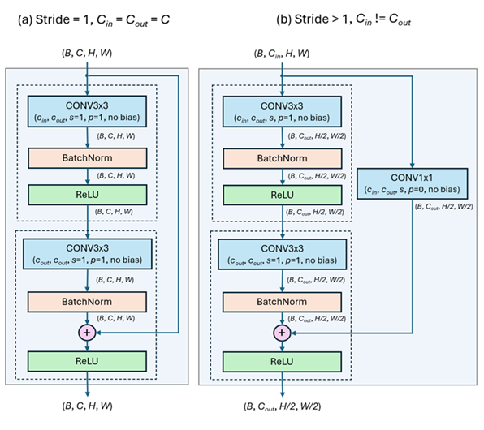

```python
class ResidualBlock(nn.Module):
    def __init__(self, blk_cin, blk_cout, blk_stride=1):
        super().__init__()

        # Main path
        self.conv1 = nn.Conv2d(blk_cin, blk_cout, kernel_size=3,
                               stride=blk_stride, padding=1, bias=False)
        self.bn1   = nn.BatchNorm2d(blk_cout)
        self.conv2 = nn.Conv2d(blk_cout, blk_cout, kernel_size=3,
                               stride=1, padding=1, bias=False)
        self.bn2 = nn.BatchNorm2d(blk_cout)

        # Skip connection
        if blk_stride != 1 or blk_cin != blk_cout:
            self.shortcut = nn.Sequential(
                nn.Conv2d(blk_cin, blk_cout, kernel_size=1,
                          stride=blk_stride, bias=False),
                nn.BatchNorm2d(blk_cout)
            )
        else:
            self.shortcut = nn.Sequential()

    def forward(self, x):
        # Main path
        out = F.relu(self.bn1(self.conv1(x)))
        out = self.bn2(self.conv2(out))

        # Skip connection and ReLU
        out += self.shortcut(x)
        out = F.relu(out)

        return out
```

## 2.1 Implement a customizable ResNet layer (Sequential Module)

Now, let's create a function to build a ResNet layer containing multiple residual blocks. The function returns a [nn.sequential](https://pytorch.org/docs/stable/generated/torch.nn.Sequential.html) module which composed of multiple residual blocks.

- The configuration for the **first** layer is different where `in_channels = blk_cin`, `out_channels = blk_cout` and `stride = s`.
- All the remaining convolutional layers have `in_channels = blk_cout`, `out_channels = blk_cout` and `stride = 1`.

Reference:

1. [nn.Sequential](https://pytorch.org/docs/stable/generated/torch.nn.Sequential.html): a container module in PyTorch that allows you to define a neural network model in a sequential manner. It stacks layers in the order they are passed, automatically forwarding inputs through them.

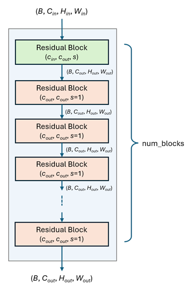

```python
def make_layer(layer_cin, layer_cout, layer_stride, num_blocks):
    """
    Create a layer composed of multiple residual blocks

    Args:
        block: The block class to use (ResidualBlock)
        blk_cin: Number of input channels
        blk_cout: Number of output channels
        num_blocks: Number of blocks in this layer
        blk_stride: Stride for the first block (to reduce dimensions if needed)

    Returns:
        nn.Sequential: A sequence of residual blocks forming a layer
    """
    # Create a list to hold the blocks
    resblks = []

    # add the first residual block into resblk. The first block may reduce dimensions
    resblks.append(ResidualBlock(layer_cin, layer_cout, layer_stride))

    # Add remaining residual blocks into resblks
    for _ in range(1, num_blocks):
        resblks.append(ResidualBlock(layer_cout, layer_cout, 1))

    # create a sequential container for layer
    layer = nn.Sequential(*resblks)

    return layer
```

## 2.2 Implementing a Customizable ResNet Architecture

Now, let's put everything together to create a complete ResNet model which can be configured to implement ResNet18 or ResNet34.

Given an input image of size (B, 3, 128, 128), the output of the layers are shown below:

| Layer | ResNet18 | ResNet34 | Output Shape) |
| --- | --- | --- | --- |
| Input | RGB Image | (same) | (B, 3, 128, 128) |
| conv1 | 7x7 conv, 64 filter, s=2, p=3 | (same) | (B,64, 64, 64) |
| bn1 + relu | Batch norm + ReLU | (same) | (B, 64, 64, 64) |
| maxpool | 3x3 max pool, s=2, p=1 | (same) | (B, 64, 32, 32) |
| layer1 | 2 residual blocks, 64 filters, s=1 | 3 residual blocks, 64 filters, s=1 | B, 64, 32, 32) |
| layer2 | 2 residual blocks, 128 filters, s=2 | 4 residual blocks, 128 filters, s=2 | (B, 128, 16, 16) |
| layer3 | 2 residual blocks, 256 filters, s=2 | 6 residual blocks, 256 filters, s=2 | (B, 256, 8, 8) |
| layer4 | 2 residual blocks, 512 filters, s=2 | 3 residual blocks, 512 filters, s=2 | (B, 512, 4, 4) |
| avgpool | Global average pooling | (same) | (B, 512, 1, 1) |
| flatten | Flatten | (same) | (B, 512) |
| fc | Fully connected, 10 classes | (same) | (B, 10) |

```python
class ResNet(nn.Module):
    def __init__(self, num_residual_blocks, num_classes):
        super().__init__()

        # Initial convolution and pooling
        self.conv1 = nn.Conv2d(3, 64, kernel_size=7, stride=2, padding=3, bias=False)
        self.bn1 = nn.BatchNorm2d(64)
        self.maxpool = nn.MaxPool2d(kernel_size=3, stride=2, padding=1)

        # Residual layers
        self.layer1 = make_layer(blk_cin=64,  blk_cout=64, blk_stride=1,  num_blocks=num_residual_blocks[0])
        self.layer2 = make_layer(blk_cin=64,  blk_cout=128, blk_stride=2, num_blocks=num_residual_blocks[1])
        self.layer3 = make_layer(blk_cin=128, blk_cout=256, blk_stride=2, num_blocks=num_residual_blocks[2])
        self.layer4 = make_layer(blk_cin=256, blk_cout=512, blk_stride=2, num_blocks=num_residual_blocks[3])

        # Global average pooling and final fully connected layer
        self.avgpool = nn.AdaptiveAvgPool2d((1, 1))
        self.fc = nn.Linear(512, num_classes)

    def forward(self, x):
        # Initial convolution and pooling
        x = F.relu(self.bn1(self.conv1(x)))
        x = self.maxpool(x)

        # Residual layers
        x = self.layer1(x)
        x = self.layer2(x)
        x = self.layer3(x)
        x = self.layer4(x)

        # Global average pooling and classification
        x = self.avgpool(x)
        x = torch.flatten(x, 1)  # Flatten all dimensions except batch
        x = self.fc(x)

        return x
```

### Train a ResNet18 model

```python
def resnet18(device):
    return ResNet(num_residual_blocks = [2, 2, 2, 2], num_classes=10).to(device)
```

```python
model = resnet18(device)
optimizer = optim.SGD(model.parameters(), lr=config["lr"], momentum=config["momentum"])
```

Train the model

```python
train(model, optimizer, criterion, train_loader, test_loader, config, device)
```

```
[Epoch  1, iter   500] train_loss: 1.785
[Epoch  1, iter  1000] train_loss: 1.497
[Epoch  1, iter  1500] train_loss: 1.370
[Epoch  1, iter  2000] train_loss: 1.258
[Epoch  1, iter  2500] train_loss: 1.185
[Epoch  1, iter  3000] train_loss: 1.094
[Epoch  1, iter  3125] train_loss: 1.039
--> Epoch 1 completed. Train Loss: 1.039, Test Loss: 0.066, Test Accuracy: 61.56%

[Epoch  2, iter   500] train_loss: 1.027
[Epoch  2, iter  1000] train_loss: 0.955
[Epoch  2, iter  1500] train_loss: 0.927
[Epoch  2, iter  2000] train_loss: 0.903
[Epoch  2, iter  2500] train_loss: 0.885
[Epoch  2, iter  3000] train_loss: 0.849
[Epoch  2, iter  3125] train_loss: 0.818
--> Epoch 2 completed. Train Loss: 0.818, Test Loss: 0.048, Test Accuracy: 72.77%

[Epoch  3, iter   500] train_loss: 0.741
[Epoch  3, iter  1000] train_loss: 0.781
[Epoch  3, iter  1500] train_loss: 0.766
[Epoch  3, iter  2000] train_loss: 0.742
[Epoch  3, iter  2500] train_loss: 0.729
[Epoch  3, iter  3000] train_loss: 0.705
[Epoch  3, iter  3125] train_loss: 0.693
--> Epoch 3 completed. Train Loss: 0.693, Test Loss: 0.044, Test Accuracy: 76.06%

[Epoch  4, iter   500] train_loss: 0.663
[Epoch  4, iter  1000] train_loss: 0.664
[Epoch  4, iter  1500] train_loss: 0.629
[Epoch  4, iter  2000] train_loss: 0.632
[Epoch  4, iter  2500] train_loss: 0.628
[Epoch  4, iter  3000] train_loss: 0.612
[Epoch  4, iter  3125] train_loss: 0.633
--> Epoch 4 completed. Train Loss: 0.633, Test Loss: 0.039, Test Accuracy: 79.11%

[Epoch  5, iter   500] train_loss: 0.554
[Epoch  5, iter  1000] train_loss: 0.573
[Epoch  5, iter  1500] train_loss: 0.544
[Epoch  5, iter  2000] train_loss: 0.576
```

[output cut: 34 more lines]

```
[Epoch  9, iter  1500] train_loss: 0.380
[Epoch  9, iter  2000] train_loss: 0.387
[Epoch  9, iter  2500] train_loss: 0.401
[Epoch  9, iter  3000] train_loss: 0.368
[Epoch  9, iter  3125] train_loss: 0.412
--> Epoch 9 completed. Train Loss: 0.412, Test Loss: 0.030, Test Accuracy: 84.21%

[Epoch 10, iter   500] train_loss: 0.334
[Epoch 10, iter  1000] train_loss: 0.352
[Epoch 10, iter  1500] train_loss: 0.342
[Epoch 10, iter  2000] train_loss: 0.341
[Epoch 10, iter  2500] train_loss: 0.349
[Epoch 10, iter  3000] train_loss: 0.344
[Epoch 10, iter  3125] train_loss: 0.340
--> Epoch 10 completed. Train Loss: 0.340, Test Loss: 0.029, Test Accuracy: 84.73%
```

### Train a ResNet34 model

```python
def resnet34(device):
    return ResNet(num_residual_blocks = [3, 4, 6, 3], num_classes=10).to(device)
```

```python
model = resnet34(device)
optimizer = optim.SGD(model.parameters(), lr=config["lr"], momentum=config["momentum"])

train(model, optimizer, criterion, train_loader, test_loader, config, device)
```

```
[Epoch  1, iter   500] train_loss: 1.889
[Epoch  1, iter  1000] train_loss: 1.592
[Epoch  1, iter  1500] train_loss: 1.449
[Epoch  1, iter  2000] train_loss: 1.350
[Epoch  1, iter  2500] train_loss: 1.286
[Epoch  1, iter  3000] train_loss: 1.174
[Epoch  1, iter  3125] train_loss: 1.105
--> Epoch 1 completed. Train Loss: 1.105, Test Loss: 0.075, Test Accuracy: 58.74%

[Epoch  2, iter   500] train_loss: 1.088
[Epoch  2, iter  1000] train_loss: 1.035
[Epoch  2, iter  1500] train_loss: 0.976
[Epoch  2, iter  2000] train_loss: 0.931
[Epoch  2, iter  2500] train_loss: 0.909
[Epoch  2, iter  3000] train_loss: 0.856
[Epoch  2, iter  3125] train_loss: 0.848
--> Epoch 2 completed. Train Loss: 0.848, Test Loss: 0.050, Test Accuracy: 72.58%

[Epoch  3, iter   500] train_loss: 0.793
[Epoch  3, iter  1000] train_loss: 0.769
[Epoch  3, iter  1500] train_loss: 0.784
[Epoch  3, iter  2000] train_loss: 0.746
[Epoch  3, iter  2500] train_loss: 0.734
[Epoch  3, iter  3000] train_loss: 0.730
[Epoch  3, iter  3125] train_loss: 0.726
--> Epoch 3 completed. Train Loss: 0.726, Test Loss: 0.039, Test Accuracy: 77.57%

[Epoch  4, iter   500] train_loss: 0.659
[Epoch  4, iter  1000] train_loss: 0.652
[Epoch  4, iter  1500] train_loss: 0.666
[Epoch  4, iter  2000] train_loss: 0.623
[Epoch  4, iter  2500] train_loss: 0.620
[Epoch  4, iter  3000] train_loss: 0.636
[Epoch  4, iter  3125] train_loss: 0.571
--> Epoch 4 completed. Train Loss: 0.571, Test Loss: 0.039, Test Accuracy: 78.81%

[Epoch  5, iter   500] train_loss: 0.555
[Epoch  5, iter  1000] train_loss: 0.553
[Epoch  5, iter  1500] train_loss: 0.550
[Epoch  5, iter  2000] train_loss: 0.536
```

[output cut: 25 more lines]

[output not shown]

# Section 3: Using nn.ModuleList to implement a list of layers

In the above, we have created customizable layer by using the function `make_layer` which returns a [Sequential](https://pytorch.org/docs/stable/generated/torch.nn.Sequential.html) module. In this section, we try an alternative way to implement a custom `Layer` module that stacks multiple residual blocks in a ResNet architecture using [n.ModuleList](https://pytorch.org/docs/stable/generated/torch.nn.ModuleList.html). The `nn.ModuleList` works like a list but it additionally registers all contained modules as prt of the model.

### Customizable `Layer` module class with `nn.ModuleList`

Implement a customizable `Layer` class where `nn.ModuleList` is used to create a dynamic list of layers.

- Accept parameters for input channels, output channels, number of blocks, and stride
- Create a list of ResidualBlock modules:
  - The first block handles channel expansion and downsampling (if stride > 1) where the first residual block uses the user defined `stride` setting.
  - Subsequent blocks maintain the same channel dimensions with stride=1
- Store these blocks in an `nn.ModuleList`
- Implement a forward method that sequentially passes input through all blocks

```python
class Layer(nn.Module):
    def __init__(self, layer_cin, layer_cout, layer_stride, num_blocks):
        super().__init__()
        layers = [ResidualBlock(layer_cin, layer_cout, layer_stride)]
        for _ in range(1, num_blocks):
            layers.append(ResidualBlock(layer_cout, layer_cout, 1))

        self.layers = nn.ModuleList(layers)

    def forward(self, x):
        for layer in self.layers:
            x = layer(x)
        return x
```

Create the ResNet using the `Layer` class.

```python
class ResNet_v2(nn.Module):
    def __init__(self, num_residual_blocks, num_classes):
        super().__init__()

        # Initial convolution and pooling
        self.conv1 = nn.Conv2d(3, 64, kernel_size=7, stride=2, padding=3, bias=False)
        self.bn1 = nn.BatchNorm2d(64)
        self.maxpool = nn.MaxPool2d(kernel_size=3, stride=2, padding=1)

        # Residual layers
        self.layer1 = Layer(64, 64,   layer_stride=1, num_blocks=num_residual_blocks[0])
        self.layer2 = Layer(64, 128,  layer_stride=2, num_blocks=num_residual_blocks[1])
        self.layer3 = Layer(128, 256, layer_stride=2, num_blocks=num_residual_blocks[2])
        self.layer4 = Layer(256, 512, layer_stride=2, num_blocks=num_residual_blocks[3])

        # Global average pooling and final fully connected layer
        self.avgpool = nn.AdaptiveAvgPool2d((1, 1))
        self.fc = nn.Linear(512, num_classes)

    def forward(self, x):
        # Initial convolution and pooling
        x = F.relu(self.bn1(self.conv1(x)))
        x = self.maxpool(x)

        # Residual layers
        x = self.layer1(x)
        x = self.layer2(x)
        x = self.layer3(x)
        x = self.layer4(x)

        # Global average pooling and classification
        x = self.avgpool(x)
        x = torch.flatten(x, 1)  # Flatten all dimensions except batch
        x = self.fc(x)

        return x
```

```python
def resnet18_v2(device):
    return ResNet_v2(num_residual_blocks = [2, 2, 2, 2], num_classes=10).to(device)
```

```python
model = resnet18_v2(device)
optimizer = optim.SGD(model.parameters(), lr=config["lr"], momentum=config["momentum"])
```

Train the resnet18 model.

```python
config = {"num_epochs": 5,
          "batch_size": 16,
          "lr": 0.001,
          "momentum": 0.9}

train(model, optimizer, criterion, train_loader, test_loader, config, device)
```

[output not shown]

--- End of Lab06---